# lab 2

Ren Meng

2020/7/7

##Part 1

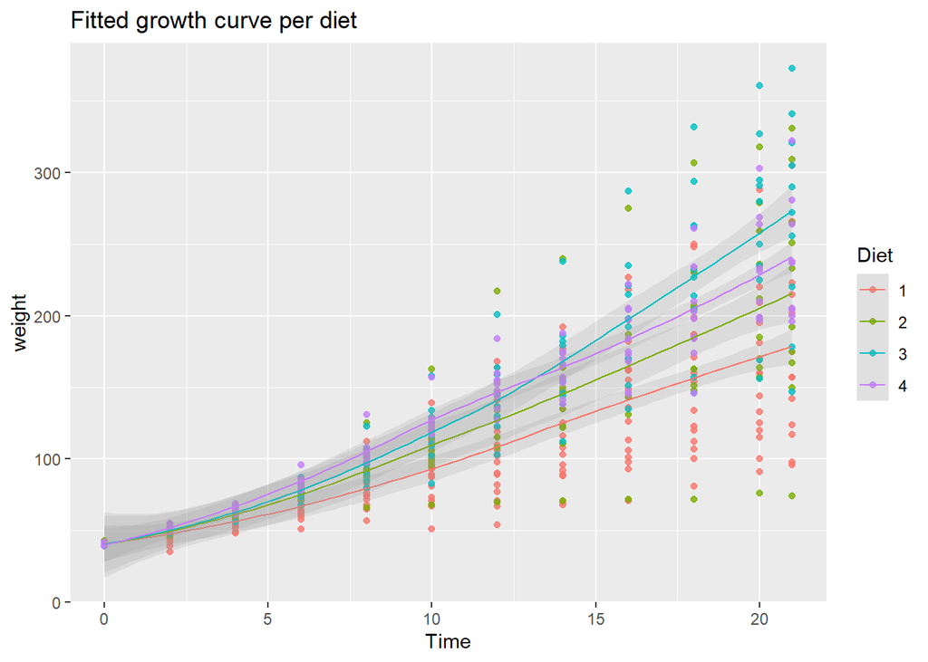

```r
p1 <- ggplot(ChickWeight, aes(x=Time, y=weight, colour=Diet)) +
    geom_point(alpha=.8) +
    geom_smooth(alpha=.2, size=0.5) +
    ggtitle("Fitted growth curve per diet")
p1
```

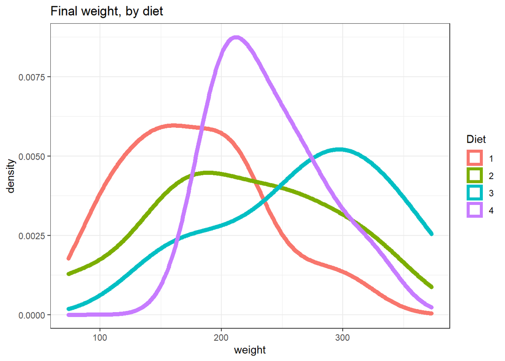

```r
p2 <- ggplot(subset(ChickWeight, Time==21), aes(x=weight, colour=Diet)) +
    geom_density(size=2) +
    ggtitle("Final weight, by diet")+theme_bw()
p2
```

p2画的是ChickWeight中times值为21的子集的数据。ase（）将weight设成了x轴，，不同颜色值表示不同的对象的diet值。geom_density()做出一条拟合曲线。

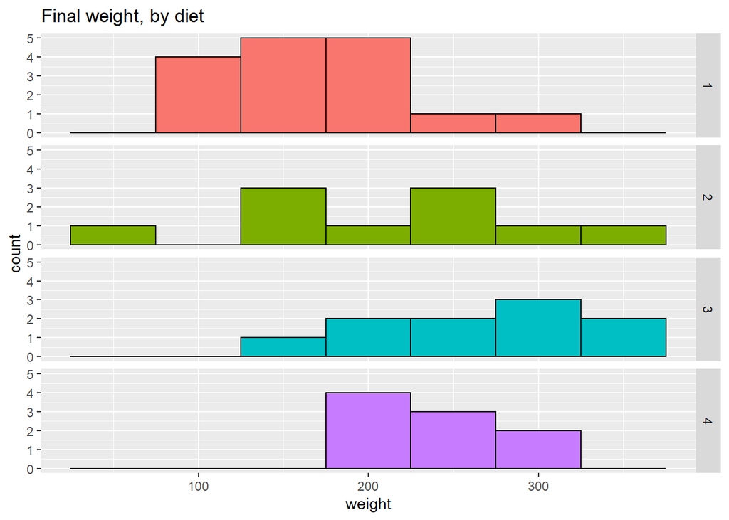

```r
p3 <- ggplot(subset(ChickWeight, Time==21), aes(x=weight, fill=Diet)) +
    geom_histogram(colour="black", binwidth=50) +
    facet_grid(Diet ~ .) +
    ggtitle("Final weight, by diet") +
    theme(legend.position="none")        # No legend (redundant in this graph)
p3
```

geom_histogram()：直方图又称质量分布图，由一系列高度不等的纵向条纹或线段表示数据分布的情况。其中binwidth参数可以用来设置组距，通过组距调节平滑度。 p3做出分面直方图，取ChickWeight中times值为21的子集的数据。x轴是weight，通过diet的不同形成四个对象的直方图。

##Part 2:exercise

```r
#Southeast US National Parks
se <- read_csv("data/se.csv")
head(se)
```

```
## # A tibble: 6 x 7
##   region state code  park_name              type          visitors  year
##   <chr>  <chr> <chr> <chr>                  <chr>            <dbl> <dbl>
## 1 SE     FL    BISC  Biscayne National Park National Park    78147  1972
## 2 SE     FL    BISC  Biscayne National Park National Park   243100  1973
## 3 SE     FL    BISC  Biscayne National Park National Park   409700  1974
## 4 SE     FL    BISC  Biscayne National Park National Park   351500  1975
## 5 SE     FL    BISC  Biscayne National Park National Park   339100  1976
## 6 SE     FL    BISC  Biscayne National Park National Park   205900  1977
```

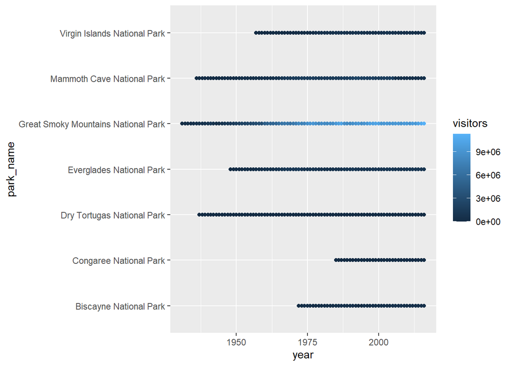

```r
ggplot(se,aes(y=park_name,x=year,colour=visitors))+
  geom_point()
```

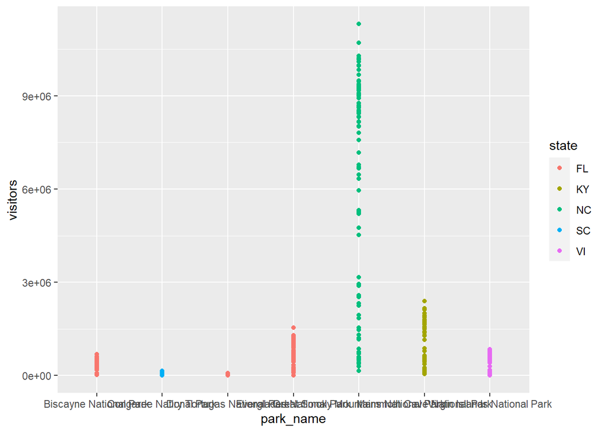

```r
ggplot(se,aes(y=visitors,x=park_name,colour=state))+
  geom_point()
```

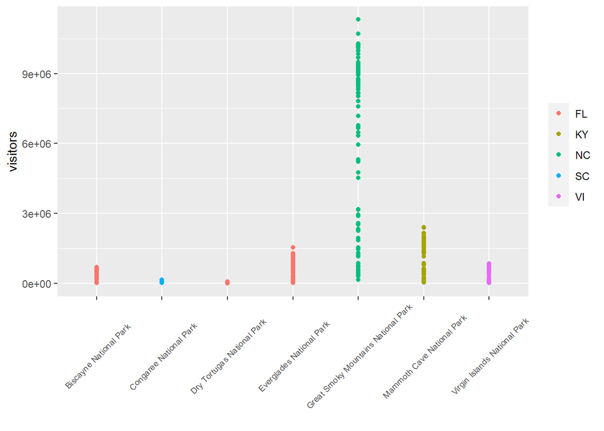

```r
ggplot(se,aes(y=visitors,x=park_name,colour=state))+
  geom_point()+
  theme(axis.text.x = element_text(angle = 45, hjust = 0.5, vjust = 0.5,size=7)) +
    theme(legend.title=element_blank())+
  xlab("")
```

In the code below, why isn’t the data showing up?

```r
ggplot(data = se, aes(x = year, y = visitors))
```

没有在上面加入点图层，线图层或其他图层。